# case_study 3

```r
# Importing packages
library(quantmod) # To access yfinance
library(bootUR) # For adf
library(forecast) # For ARIMA models, Acf and Pacf
library(vars) # For the VAR
library(zoo)
```

```r
# Data loading
jpm_data <- getSymbols('JPM', src='yahoo', from = "2005-01-01", to = "2025-12-31", auto.assign = FALSE)
```

# Data Exploration

```r
jpm_adj <- Ad(jpm_data) # Use adjusted close data as the price.
```

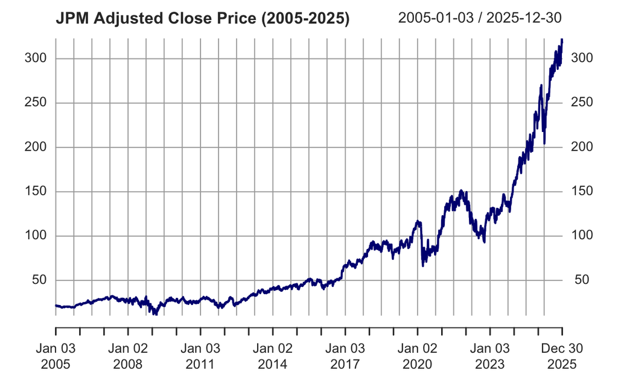

```r
plot(jpm_adj, main = "JPM Adjusted Close Price (2005-2025)", col = "navy", major.ticks = "years")
```

By observing the plot of the Adj-Close time series we can probably see that it is non-stationary. It clearly has an upwards trend.

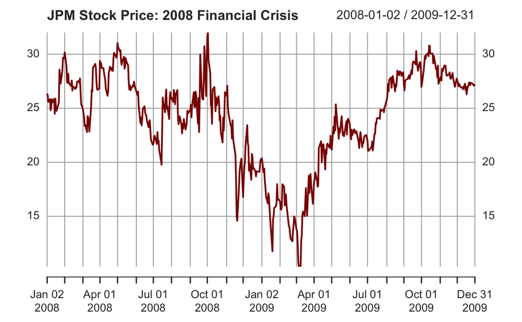

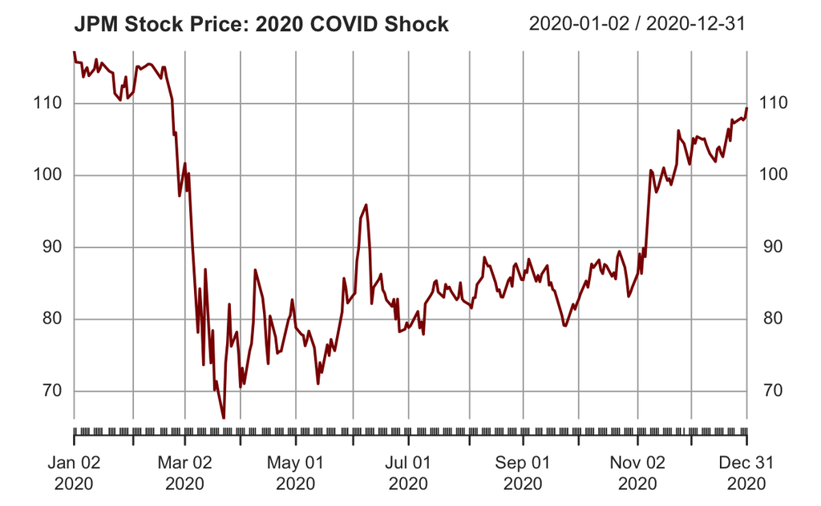

```r
crises <- list(
  "2008 Financial Crisis" = c(start = "2008-01-01", end = "2009-12-31"),
  "2020 COVID Shock"     = c(start = "2020-01-01", end = "2020-12-31")
)

for (name in names(crises)) {
  date_range <- paste(crises[[name]]["start"], crises[[name]]["end"], sep = "/")

  crisis_subset <- jpm_adj[date_range]

  print(plot(crisis_subset,
       main = paste("JPM Stock Price:", name),
       col = "darkred",
       major.ticks = "months",
       grid.ticks.on = "months"))
}
```

# Unit Root Tests

We use the ADF test for the Pantula Principle. The Pantula principle requires us to set a dmax, in this case it is sensible to choose dmax = 2. We will perform ADF tests for series differentiated dmax-times until 0 or until we fail to reject the null hypothesis of the ADF test that the series is non-stationary (has unit root) and is I(d + 1).

```r
jpm_price <- na.omit(jpm_adj)
```

```r
diff2_jpm <- diff(jpm_price, differences = 2)[-c(1, 2)]
adf_d2 <- adf(diff2_jpm, deterministics = "none")
adf_d2
```

```
    Two-step ADF test (with none) on a single time series

data: JPM.Adjusted
null hypothesis: Series has a unit root
alternative hypothesis: Series is stationary

             estimate largest root statistic p-value
JPM.Adjusted               -0.5434    -133.5   1e-04
```

For d = 2, we reject the null-hypothesis, thus the 2-times differentiated series is stationary.

```r
diff1_jpm <- diff(jpm_price, differences = 1)[-1]
adf_d1 <- adf(diff1_jpm, deterministics = "intercept")
adf_d1
```

```
    Two-step ADF test (with intercept) on a single time series

data: JPM.Adjusted
null hypothesis: Series has a unit root
alternative hypothesis: Series is stationary

             estimate largest root statistic p-value
JPM.Adjusted               0.01016    -49.91   1e-04
```

We continue to d = 1, we also reject the H0, and thus, the 1-time differentiated series is stationary.

```r
adf_d0 <- adf(jpm_price, deterministics = "trend")
adf_d0
```

```
    Two-step ADF test (with trend) on a single time series

data: JPM.Adjusted
null hypothesis: Series has a unit root
alternative hypothesis: Series is stationary

             estimate largest root statistic p-value
JPM.Adjusted                 1.001     1.339       1
```

Finally, for d = 0, we fail to reject the H0 and thus the adjusted close series is non-stationary because it has a unit root.

From this we can conclude that the series is I(1).

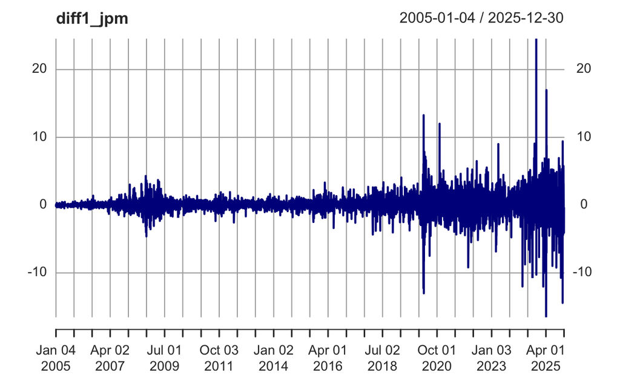

```r
plot(diff1_jpm, col = "darkblue")
```

# ARIMA Models for the Price Series

```r
jpm_price <- na.omit(jpm_adj)

diff_jpm <- diff(jpm_price)[-1]
```

We know the price series is I(1) se we now use the first differences series

```r
par(mfrow = c(1, 2))
Acf(diff_jpm, main = "ACF of First Differences (ΔY_t)")
Pacf(diff_jpm, main = "PACF of First Differences (ΔY_t)")
```

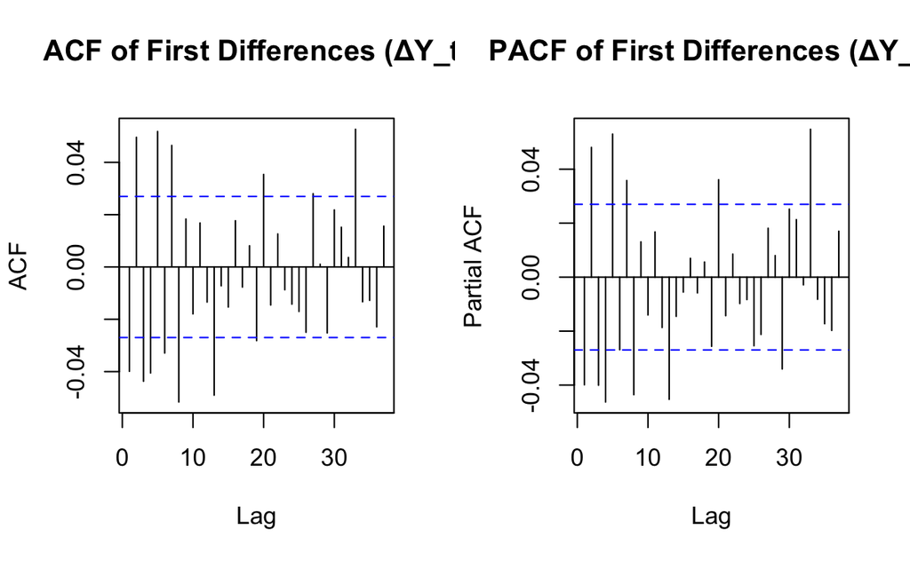

```r
par(mfrow = c(1, 1))
```

```r
fit_arima111 <- Arima(jpm_price, order = c(1, 1, 1), include.drift = TRUE)
fit_arima212 <- Arima(jpm_price, order = c(2, 1, 2), include.drift = TRUE)
fit_arima010 <- Arima(jpm_price, order = c(0, 1, 0), include.drift = TRUE)
```

Standard R functions like stats::arima() only allow a drift term when d = 0. The forecast::Arima() allows inclusion of a constant term c when we differentiatie once. And since we know our series is I(1) we need to use the forecast package.

```r
aicc_table <- data.frame(
  Model = c("ARIMA(0,1,0) with drift", "ARIMA(1,1,1) with drift", "ARIMA(2,1,2) with drift"),
  AICc  = c(fit_arima010$aicc, fit_arima111$aicc, fit_arima212$aicc)
)
print(aicc_table)
```

```
                    Model     AICc
1 ARIMA(0,1,0) with drift 19794.81
2 ARIMA(1,1,1) with drift 19782.42
3 ARIMA(2,1,2) with drift 19763.24
```

We choose as the best model the one with the lowest AICc, which is ARIMA(2, 1, 2).

```r
auto_fit <- auto.arima(
  jpm_price,
  d = 1,                   # We know its I(1)
  max.p = 5,               # Set max search bounds
  max.q = 5,
  stepwise = TRUE,         # Uses Hyndman-Khandakar stepwise algorithm
  approximation = FALSE,
  ic = "aicc"              # Selects model based on Corrected AIC
)

summary(auto_fit)
```

```
Series: jpm_price
ARIMA(4,1,2) with drift

Coefficients:
          ar1      ar2      ar3      ar4     ma1     ma2   drift
      -1.0828  -0.2489  -0.0014  -0.0689  1.0526  0.2623  0.0555
s.e.   0.2097   0.1879   0.0221   0.0234  0.2104  0.1804  0.0208

sigma^2 = 2.452:  log likelihood = -9858.46
AIC=19732.92   AICc=19732.95   BIC=19785.5

Training set error measures:
                       ME     RMSE       MAE        MPE     MAPE    MASE
Training set 0.0005034493 1.564772 0.8795285 -0.1090506 1.372885 1.00083
                      ACF1
Training set -0.0003131819
```

# From prices to Returns

We will use log-returns, the reasons for this decision are: - Log-returns are linearly additive over time, while simple returns must be compounded through multiplication. - When price series are long, raw prices increase rapidly, simple returns can suffer from big variance differences, while log returns scale variance and return more stationary variance properties.

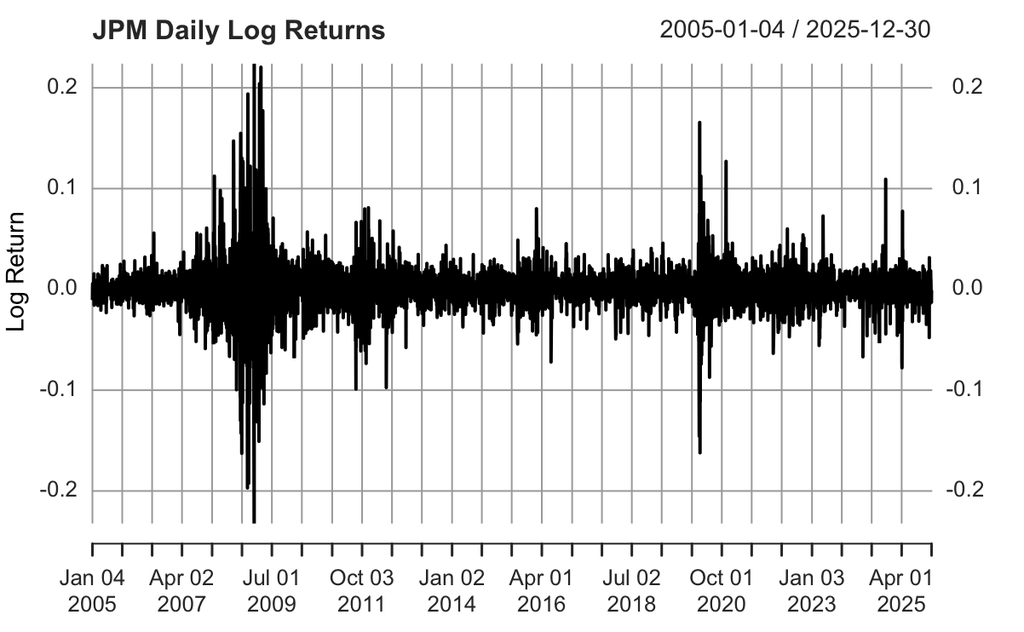

```r
jpm_returns <- na.omit(diff(log(jpm_adj)))

plot(jpm_returns, main = "JPM Daily Log Returns", ylab = "Log Return")
```

The series looks stationary from visual examination

```r
adf(jpm_returns, deterministics = "intercept")
```

```
    Two-step ADF test (with intercept) on a single time series

data: JPM.Adjusted
null hypothesis: Series has a unit root
alternative hypothesis: Series is stationary

             estimate largest root statistic p-value
JPM.Adjusted               -0.1001    -53.95   1e-04
```

We run the ADF test only with intercept because the mean of the log returns series is not exactly zero, since stock prices have an upwards trend. Using the ADF test we can reject the null hypothesis that the series has a unit root, and thus determine that our log returns are a stationary time series.

```r
par(mfrow = c(1, 2))
Acf(jpm_returns, main = "ACF of log-returns")
Pacf(jpm_returns, main = "PACF of log-returns")
```

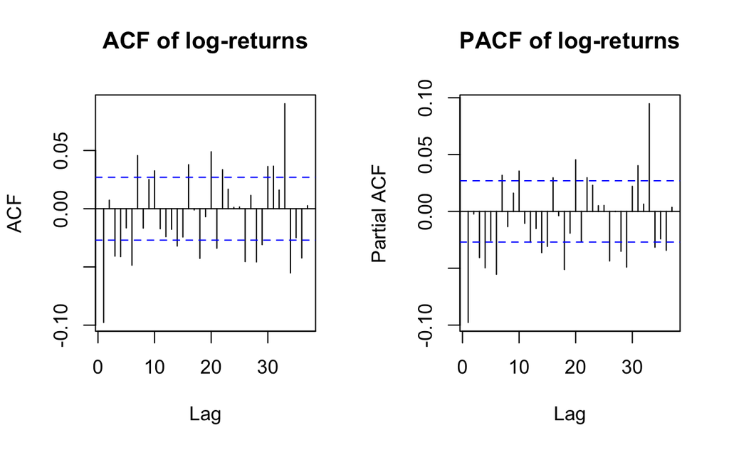

```r
par(mfrow = c(1, 1))
```

```r
auto_fit <- auto.arima(
  jpm_returns,
  d = 0,                   # We know log returns are stationary
  max.p = 5,               # Set max search bounds
  max.q = 5,
  stepwise = TRUE,
  approximation = FALSE,
  ic = "aicc"              # Selects model based on Corrected AIC
)

summary(auto_fit)
```

```
Series: jpm_returns
ARIMA(3,0,2) with non-zero mean

Coefficients:
         ar1      ar2      ar3      ma1     ma2   mean
      1.4441  -0.7106  -0.0993  -1.5496  0.8563  5e-04
s.e.  0.0443   0.0460   0.0155   0.0423  0.0465  3e-04

sigma^2 = 0.0004973:  log likelihood = 12594.21
AIC=-25174.43   AICc=-25174.41   BIC=-25128.43

Training set error measures:
                        ME       RMSE        MAE MPE MAPE      MASE       ACF1
Training set -2.341475e-06 0.02228677 0.01365551 NaN  Inf 0.6793418 0.00101219
```

From the auto.arima function we select the ARIMA(3, 0, 2).

# GARCH models: Modeling volatility

The ARIMA models we fit above model the conditional mean of the returns, assuming the errors are homoskedastic, meaning they have a constant variance. But financial returns are well known for their volatility clustering: large price changes tend to be followed by more large price changes, and small changes tend to be followed by small changes.This means the variance of the errors is not constant over time, but it is itsef autocorrelated. Even when the returns themselves are uncorrelated.

(G)ARCH models (Bollershev, 1986) shift the focus from modeling the conditional mean to modelling the conditional variance.

The GARCH(1,1):

$$r_t = \mu_t + \epsilon_t, \qquad
\epsilon_t = \sigma_t z_t, \qquad z_t \overset{iid}{\sim}
D(0,1)$$
$$\sigma_t^2 = \omega +
\alpha_1\epsilon_{t-1}^2 + \beta_1\sigma_{t-1}^2$$
Today’s conditional variance $\sigma_t^2$ depends on a constant $\omega$, yesterday’s shock squared $\epsilon_{t-1}^2$, and yesterday’s conditional variance $\sigma_{t-1}^2$. This is very similar compared to the ARMA model, but then applied to the squared residuals (variance) instead of the level of the series (mean).

Stylized facts GARCH captures and ARIMA can’t: (i)Volatility clustering (described above) (ii)Heteroskedasticity: Variance can change over time, no longer constant is in ARIMA models. (iii)Fat tails: Because of the adjusted variance at every time step, you are not forced to use a normal distribution for the error terms.Under a normal distribution, the probability of an extreme event (market crash) is calculated as really small. In real life, these extreme outliers happen much more frequently than a normal distribution predicts. (iv)Mean reverting volatility: After a shock, volatility eventually settles back toward a long-run average level. At the rate $alpha_1$ + $beta_1$.

# Checking for ARCH effects:

Before we implement the GARCH model, we first check whether there is statistical evidence for ARCH. We do this by looking at the autocorrelation of the squared returns. If returns themselves are close to white noise, but their squares are autocorrelated, there is direct evidence of volatility clustering.

```r
par(mfrow = c(1,2))
Acf(jpm_returns^2, main = "ACF of squared log-returns")

Pacf(jpm_returns^2, main= "PACF of squared log-returns")
```

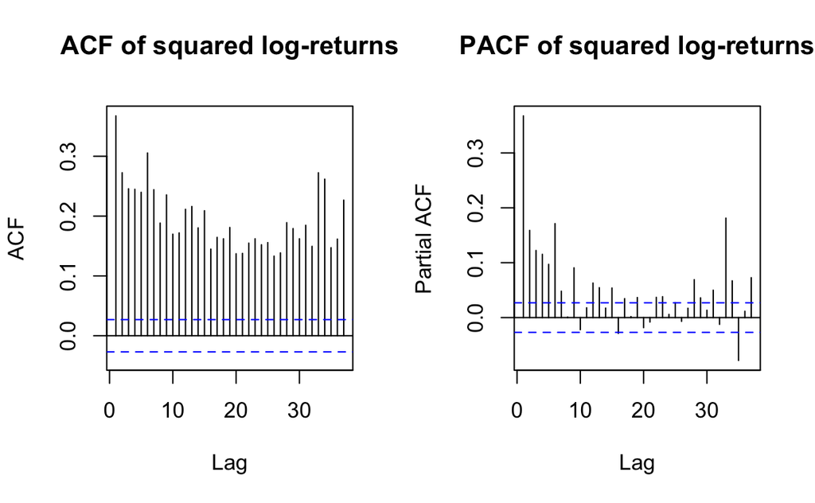

```r
par(mfrow = c(1,1))
```

```r
#ARCH-LM test (formal test for ARCH effects)
library(FinTS)
ArchTest(jpm_returns, lags = 12)
```

```
    ARCH LM-test; Null hypothesis: no ARCH effects

data:  jpm_returns
Chi-squared = 1179.9, df = 12, p-value < 2.2e-16
```

We reject the null hypothesis, so a GARCH model is necessary.

# Estimating a GARCH(1,1) model

We use the rugarch package, the standard package for GARCH models. This is because it supports many variance specifications and multiple error distributions(normal, Student-t, skewed-t, etc).

```r
#Garch(1,1) with a Student-t distribution for the #standardized errors. We do this to accomodate for the #fat tails observed in daily equity returns.
#The mean equation is specified as ARMA(3,2), matching #the auto.arima selection for the return series above.
library(rugarch)
spec_garch11 <- ugarchspec(
  variance.model = list(model = "sGARCH", garchOrder = c(1,1)),
  mean.model = list(armaOrder = c(3,2), include.mean = TRUE),
distribution.model = "std"
)
fit_garch11 <- ugarchfit(spec = spec_garch11, data = jpm_returns)
fit_garch11
```

```
*---------------------------------*
*          GARCH Model Fit        *
*---------------------------------*

Conditional Variance Dynamics
-----------------------------------
GARCH Model : sGARCH(1,1)
Mean Model  : ARFIMA(3,0,2)
Distribution    : std

Optimal Parameters
------------------------------------
        Estimate  Std. Error   t value Pr(>|t|)
mu      0.000914    0.000160    5.6965 0.000000
ar1     1.587009    0.005410  293.3434 0.000000
ar2    -0.912537    0.009384  -97.2418 0.000000
ar3    -0.040031    0.005777   -6.9296 0.000000
ma1    -1.624322    0.003080 -527.4580 0.000000
ma2     0.972246    0.001327  732.8680 0.000000
omega   0.000005    0.000002    1.8447 0.065087
alpha1  0.098949    0.019444    5.0890 0.000000
beta1   0.892579    0.021616   41.2920 0.000000
shape   4.992752    0.344550   14.4906 0.000000

Robust Standard Errors:
        Estimate  Std. Error     t value Pr(>|t|)
mu      0.000914    0.000156     5.87212  0.00000
ar1     1.587009    0.003692   429.84819  0.00000
ar2    -0.912537    0.007530  -121.17961  0.00000
ar3    -0.040031    0.004247    -9.42634  0.00000
ma1    -1.624322    0.001477 -1099.61171  0.00000
ma2     0.972246    0.003249   299.21267  0.00000
omega   0.000005    0.000008     0.59118  0.55440
alpha1  0.098949    0.058225     1.69942  0.08924
beta1   0.892579    0.067011    13.31980  0.00000
shape   4.992752    0.356459    14.00653  0.00000

LogLikelihood : 14567.27

Information Criteria
```

[output cut: 54 more lines]

```
Negative Sign Bias  2.8652 0.004184 ***
Positive Sign Bias  0.9353 0.349702
Joint Effect       14.1902 0.002657 ***


Adjusted Pearson Goodness-of-Fit Test:
------------------------------------
  group statistic p-value(g-1)
1    20     14.34       0.7634
2    30     28.92       0.4692
3    40     36.42       0.5879
4    50     44.69       0.6485


Elapsed time : 1.12702
```

# Interpreting the estimated model

```r
coef(fit_garch11)
```

```
           mu           ar1           ar2           ar3           ma1
 9.138670e-04  1.587009e+00 -9.125366e-01 -4.003067e-02 -1.624322e+00
          ma2         omega        alpha1         beta1         shape
 9.722461e-01  4.578739e-06  9.894891e-02  8.925788e-01  4.992752e+00
```

Recall that:
$$\sigma_t^2 = \omega +
\alpha_1\epsilon_{t-1}^2 + \beta_1\sigma_{t-1}^2$$
We see the small constant omega, the floor level of the variance without any shocks. $\alpha1 = 0.099$ ,so moderate reaction to new shocks: about 10% of yesterday’s squared shock feeds into today’s variance. $\beta1 = 0.893$ , so this means today’s variance carries forward roughly 89% of yesterday’s conditional variance. $\alpha1 + \beta1 = 0.9915$ , which is very close to 1. This means the model implies stationary, but only weakly stationary. The shocks to volatility die out only very slowly. Shape =4.99, this is the estimated degrees of freedom of the Student-t distribution. A value this low is strong evidence of fat tails: JPM’s daily returns show substantially more extreme outcome probability then a normal distribution would predict.

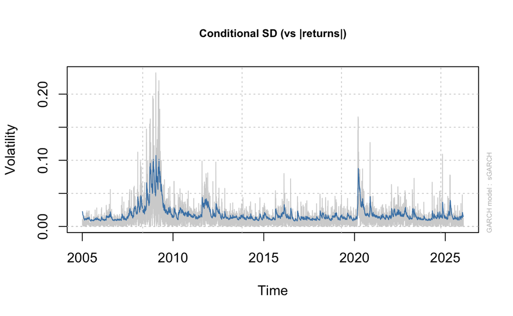

```r
plot(fit_garch11, which = 3)
```

# Diagnostics

```r
par(mfrow = c(1,2))
Acf(residuals(fit_garch11, standardize = TRUE), main = "ACF of standardized residuals")
Acf(residuals(fit_garch11, standardize = TRUE)^2, main = "ACF of squared standardized residuals")
```

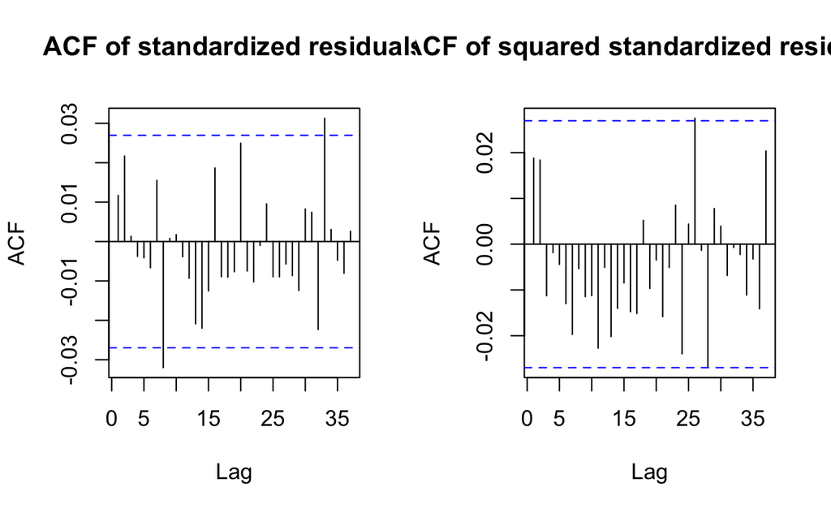

```r
par(mfrow = c(1,1))
```

```r
infocriteria(fit_garch11)
```

```
Akaike       -5.513074
Bayes        -5.500630
Shibata      -5.513081
Hannan-Quinn -5.508725
```

We have negative numbers here. This is because information criteria are built from log-likelihood. These log-likelihood uses returns, which are in our case small numbers with small variance. Making the information criteria negative. Still holds: the lower the information criteria, the better.

# Comparing the information criteria of the student-t distribution to the normal distribution.

```r
spec_norm <- ugarchspec(
  variance.model = list(model = "sGARCH", garchOrder = c(1,1)),
  mean.model = list(armaOrder = c(3,2), include.mean = TRUE),
  distribution.model = "norm"
)
fit_norm <- ugarchfit(spec = spec_norm, data = jpm_returns)

comparison <- data.frame(
  Model = c("GARCH(1,1), Student-t", "GARCH(1,1), Normal"),
  AIC = c(infocriteria(fit_garch11)[1], infocriteria(fit_norm)[1]),
  BIC = c(infocriteria(fit_garch11)[2], infocriteria(fit_norm)[2])
)
print(comparison)
```

```
                  Model       AIC      BIC
1 GARCH(1,1), Student-t -5.513074 -5.50063
2    GARCH(1,1), Normal -5.425010 -5.41381
```

We see that the difference is 0.087 for AIC and 0.086 for BIC. Since the lower the better, and this gap is far from negligible, this is clear evidence that the Student-t distribution fits the JPM returns better than the normal distribution. This confirms our choice of the student-t distribution.

# Bridging the Data Gap: Realized Range

We would like intraday data (5min/15min/1h), since yahoo finance can´t provide that we use the Parkinson’s Realized Range estimator which is:
$$RR_t = \frac{(\ln(H_t) - \ln(L_t))^2}{4
\ln(2)}$$
Basically we need The daily High price and the daily Low price, instead of adjusted close.

```r
library(lmtest)
library(sandwich)
```

Model formulation is as follows:
$$RR_t =
\beta_0 + \beta_d RR_{t-1} + \beta_w RR_{t-1}^{(w)} + \beta_m
RR_{t-1}^{(m)} + \varepsilon_t$$

```r
RR <- ((log(Hi(jpm_data)) - log(Lo(jpm_data)))^2) / (4 * log(2))
colnames(RR) <- "RR"

RR_d <- Lag(RR, 1)
RR_w <- Lag(rollmean(RR, k = 5, fill = NA, align = "right"), 1)
RR_m <- Lag(rollmean(RR, k = 22, fill = NA, align = "right"), 1)

har_range_data <- na.omit(merge(RR, RR_d, RR_w, RR_m))
colnames(har_range_data) <- c("RR", "RR_d", "RR_w", "RR_m")

har_range_model <- lm(RR ~ RR_d + RR_w + RR_m, data = har_range_data)

coeftest(har_range_model, vcov = NeweyWest(har_range_model, lag = 5))
```

```
t test of coefficients:

              Estimate Std. Error t value  Pr(>|t|)
(Intercept) 3.6134e-05 1.0311e-05  3.5043 0.0004616 ***
RR_d        4.8298e-01 9.8358e-02  4.9104 9.363e-07 ***
RR_w        1.4627e-01 8.9210e-02  1.6397 0.1011357
RR_m        2.5960e-01 7.6518e-02  3.3927 0.0006972 ***
---
Signif. codes:  0 ‘***’ 0.001 ‘**’ 0.01 ‘*’ 0.05 ‘.’ 0.1 ‘ ’ 1
```

We use Newey-West heteroskedasticity and autocorrelation consistent (HAC) standard errors because standard OLS standard errors are biased here since financial volatility series exhibit strong autocorrelation and conditional heteroskedasticity.

From the coefficient test we can see that the lagged daily RR is significant, together with the monthly RR. The weekly RR is not significant when daily RR is taken into account. I need to economically justify this!

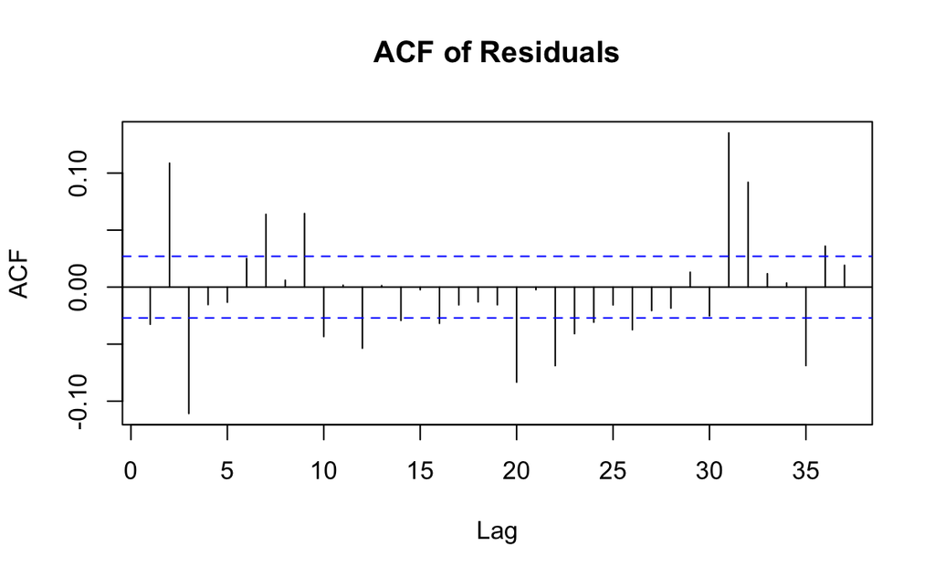

```r
res <- residuals(har_range_model)
Acf(res, main = "ACF of Residuals")
```

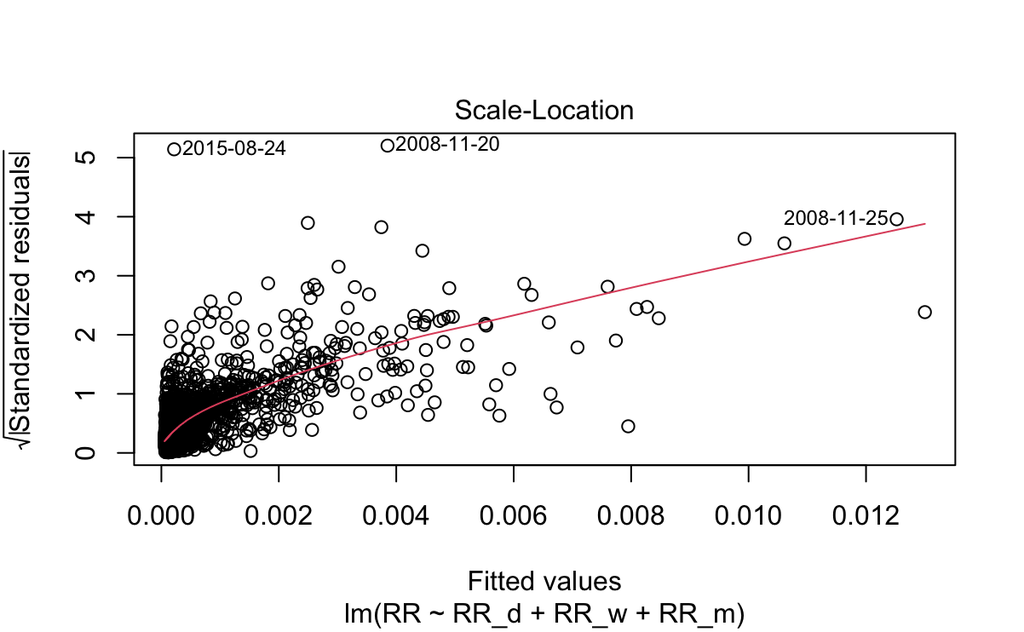

```r
plot(har_range_model, which = 3)
```

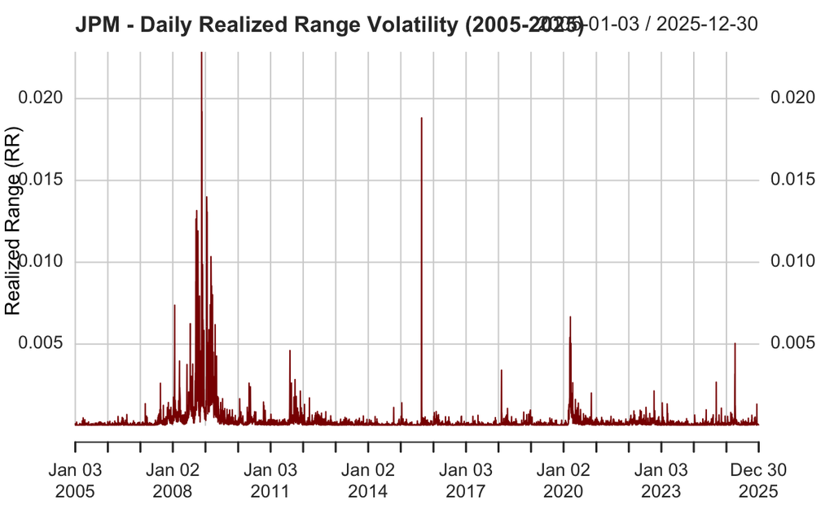

```r
plot(RR,
     main = "JPM - Daily Realized Range Volatility (2005-2025)",
     ylab = "Realized Range (RR)",
     xlab = "Date",
     col = "darkred",
     lwd = 1,
     major.ticks = "years",
     grid.ticks.on = "years",
     grid.col = "lightgray")
```

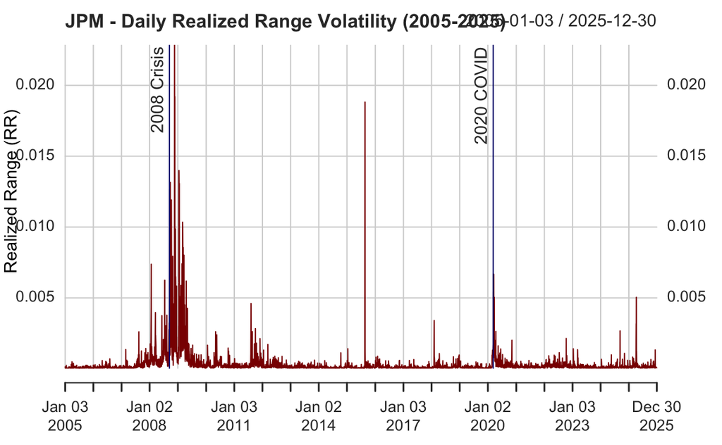

```r
# Adding a visual highlight for major economic stress periods
addEventLines(
  events = xts(c("2008 Crisis", "2020 COVID"),
               as.Date(c("2008-09-15", "2020-03-11"))),
  col = "navy",
  srt = 90,
  pos = 2
)
```

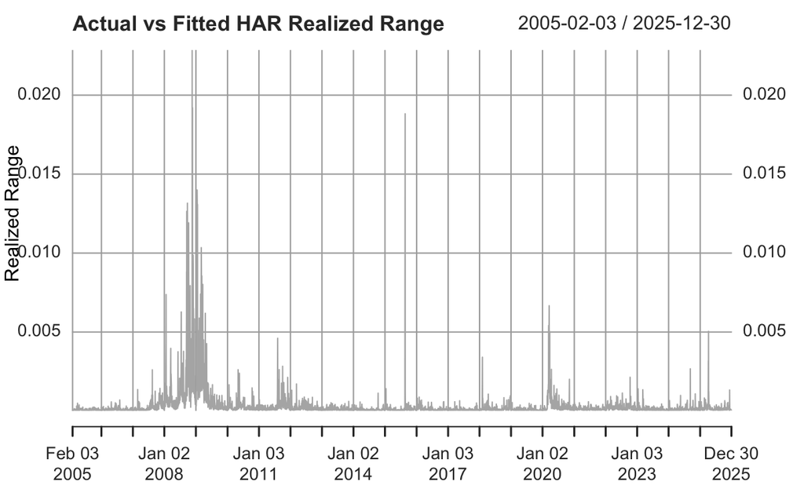

```r
# Extract fitted values from the HAR model
rr_fitted <- xts(fitted(har_range_model), order.by = index(har_range_data))

# Merge actual RR and fitted values into an xts object
# Note: fitted values start after the initial NA alignment from lagging
rr_comparison <- merge(har_range_data$RR, rr_fitted)
colnames(rr_comparison) <- c("Actual_RR", "Predicted_RR")

# 1. Plot ONLY the actual series first (Background layer: muted gray line)
plot(rr_comparison$Actual_RR,
     main = "Actual vs Fitted HAR Realized Range",
     col = "gray70",                # Light gray puts actual data in the background
     lwd = 1,
     major.ticks = "years",
     grid.ticks.on = "years",
     ylab = "Realized Range")
```

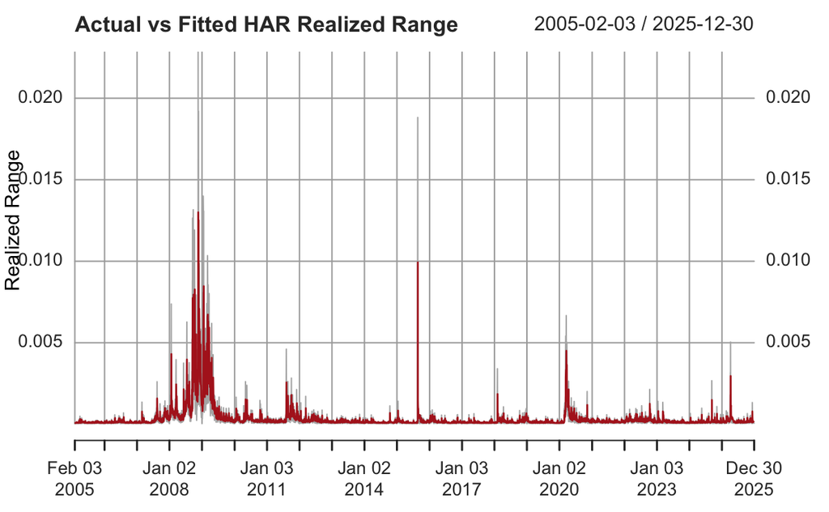

```r
# 2. Draw the predicted series on TOP (Foreground layer: bold red line)
lines(rr_comparison$Predicted_RR,
      col = "firebrick",            # Bright red brings predicted values to the front
      lwd = 1.3)
```

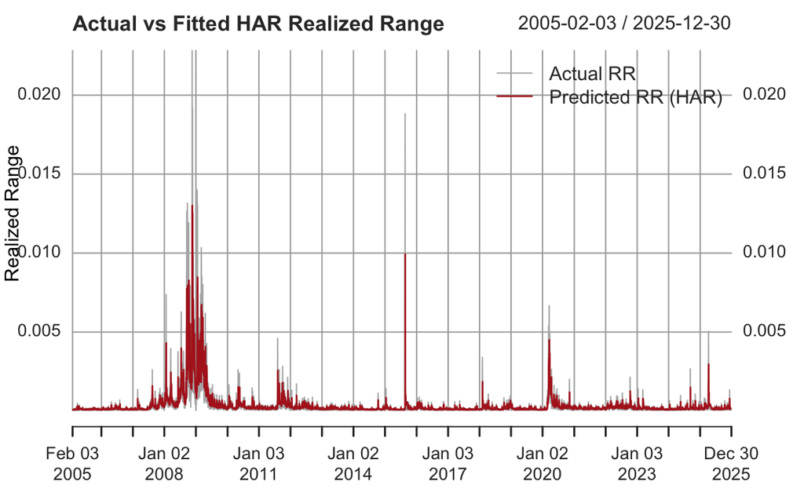

```r
# 3. Add the legend
addLegend(legend.loc = "topright",
          legend.names = c("Actual RR", "Predicted RR (HAR)"),
          col = c("gray70", "firebrick"),
          lty = c(1, 1),
          lwd = c(1, 1.3),
          bg = "white")
```

# Bridging the Data Gap: Monthly Realized Variance from Daily Data

Following the previous section, another option in case intraday data is not available is to still try to model volatility but raising the aggregation level to monthly. This is done by:
$$RV_{m} = \sum_{i \in \text{month}}
r_{i}^2$$
The formulated model is:
$$RV_{m} = \beta_0 + \beta_1 RV_{m-1} + \beta_3
RV_{m-1}^{(3)} + \beta_{12} RV_{m-1}^{(12)} + \varepsilon_m$$

```r
rv_monthly <- apply.monthly(jpm_returns, function(x) sum(x^2, na.rm = TRUE))
colnames(rv_monthly) <- "RV_m"

RV_m1  <- Lag(rv_monthly, 1)
RV_m3  <- Lag(rollmean(rv_monthly, k = 3, fill = NA, align = "right"), 1)
RV_m12 <- Lag(rollmean(rv_monthly, k = 12, fill = NA, align = "right"), 1)

# 4. Combine and remove NA values generated by rolling/lagging
har_monthly_data <- na.omit(merge(rv_monthly, RV_m1, RV_m3, RV_m12))
colnames(har_monthly_data) <- c("RV_m", "RV_m1", "RV_m3", "RV_m12")

# 5. Estimate the Monthly HAR model
har_monthly_model <- lm(RV_m ~ RV_m1 + RV_m3 + RV_m12, data = har_monthly_data)

# 6. Output summary with robust standard errors
coeftest(har_monthly_model, vcov = NeweyWest(har_monthly_model))
```

```
t test of coefficients:

              Estimate Std. Error t value Pr(>|t|)
(Intercept)  0.0030263  0.0014018  2.1588  0.03187 *
RV_m1        0.0279180  0.2743767  0.1018  0.91904
RV_m3        0.8597288  0.4094822  2.0996  0.03683 *
RV_m12      -0.1604653  0.1468928 -1.0924  0.27577
---
Signif. codes:  0 ‘***’ 0.001 ‘**’ 0.01 ‘*’ 0.05 ‘.’ 0.1 ‘ ’ 1
```

From the coefficient test we can see that the only significant coefficient is the medium term volatility (quarterly). This makes us think that the primary market predictor for a stock like JPM is the intermediate market memory.

Issue: Aggregartion bias: Aggregating daily data to monthly realized variance smooths out single-month noise, shifting structural persistence toward quarterly trends.

# A Multivariate Extension: Modeling Spillovers.

```r
# 1. Collect data for JPM, BAC, and MSFT (2005-2025)
tickers <- c("JPM", "BAC", "MSFT")
multi_data <- new.env()
getSymbols(tickers, src = "yahoo", from = "2005-01-01", to = "2025-12-31", env = multi_data)
```

```
[1] "JPM"  "BAC"  "MSFT"
```

```r
# 2. Compute Daily Realized Range (RR) for each stock
calc_rr <- function(xts_obj) {
  rr <- ((log(Hi(xts_obj)) - log(Lo(xts_obj)))^2) / (4 * log(2))
  rr[rr <= 0] <- NA
  colnames(rr) <- "RR"
  return(rr)
}

rr_jpm <- calc_rr(multi_data$JPM)
rr_bac <- calc_rr(multi_data$BAC)
rr_msft <- calc_rr(multi_data$MSFT)

# 3. Construct HAR components (Daily, Weekly (5-day rolling), Monthly (22-day rolling))
make_har_features <- function(rr_series) {
  y <- log(rr_series)
  d <- stats::lag(log(rr_series), 1)
  w <- stats::lag(log(rollmean(rr_series, k = 5, fill = NA, align = "right")), 1)
  m <- stats::lag(log(rollmean(rr_series, k = 22, fill = NA, align = "right")), 1)
  res <- na.omit(merge(y, d, w, m))
  colnames(res) <- c("RR", "RR_d", "RR_w", "RR_m")
  return(res)
}

# 4. Apply your make_har_features function to each asset's Realized Range series
har_jpm <- make_har_features(rr_jpm)
har_bac <- make_har_features(rr_bac)
har_msft <- make_har_features(rr_msft)
colnames(har_jpm) <- paste0("JPM_", c("RR", "d", "w", "m"))
colnames(har_bac) <- paste0("BAC_", c("RR", "d", "w", "m"))
colnames(har_msft) <- paste0("MSFT_", c("RR", "d", "w", "m"))

m_har_data <- na.omit(merge(har_jpm, har_bac, har_msft))

# --- Equation 1: JPM M-HAR Model ---
mhar_jpm_model <- lm(JPM_RR ~ JPM_d + JPM_w + JPM_m +
                              BAC_d + BAC_w + BAC_m +
                              MSFT_d + MSFT_w + MSFT_m,
                     data = m_har_data)

# --- Equation 2: BAC M-HAR Model ---
mhar_bac_model <- lm(BAC_RR ~ JPM_d + JPM_w + JPM_m +
                              BAC_d + BAC_w + BAC_m +
                              MSFT_d + MSFT_w + MSFT_m,
                     data = m_har_data)

# --- Equation 3: MSFT M-HAR Model ---
mhar_msft_model <- lm(MSFT_RR ~ JPM_d + JPM_w + JPM_m +
                               BAC_d + BAC_w + BAC_m +
                               MSFT_d + MSFT_w + MSFT_m,
                      data = m_har_data)
```

```r
cat("\n=== JPM M-HAR Spillovers ===\n")
```

```
=== JPM M-HAR Spillovers ===
```

```r
print(coeftest(mhar_jpm_model, vcov = NeweyWest(mhar_jpm_model, lag = 5)))
```

```
t test of coefficients:

             Estimate Std. Error t value  Pr(>|t|)
(Intercept) -0.753908   0.164861 -4.5730 4.919e-06 ***
JPM_d        0.156978   0.022476  6.9844 3.217e-12 ***
JPM_w        0.179044   0.047817  3.7444 0.0001828 ***
JPM_m        0.449699   0.061748  7.2828 3.752e-13 ***
BAC_d        0.101135   0.020181  5.0114 5.582e-07 ***
BAC_w        0.062604   0.042146  1.4854 0.1374945
BAC_m       -0.067207   0.051407 -1.3074 0.1911482
MSFT_d       0.071750   0.017442  4.1136 3.955e-05 ***
MSFT_w       0.071864   0.028659  2.5075 0.0121884 *
MSFT_m      -0.092773   0.035304 -2.6278 0.0086191 **
---
Signif. codes:  0 ‘***’ 0.001 ‘**’ 0.01 ‘*’ 0.05 ‘.’ 0.1 ‘ ’ 1
```

```r
cat("\n=== BAC M-HAR Spillovers ===\n")
```

```
=== BAC M-HAR Spillovers ===
```

```r
print(coeftest(mhar_bac_model, vcov = NeweyWest(mhar_bac_model, lag = 5)))
```

```
t test of coefficients:

             Estimate Std. Error t value  Pr(>|t|)
(Intercept) -0.611325   0.161728 -3.7800 0.0001586 ***
JPM_d        0.109784   0.022732  4.8295 1.407e-06 ***
JPM_w        0.066989   0.042652  1.5706 0.1163395
JPM_m       -0.108995   0.051177 -2.1298 0.0332383 *
BAC_d        0.194924   0.021715  8.9764 < 2.2e-16 ***
BAC_w        0.175754   0.042478  4.1376 3.565e-05 ***
BAC_m        0.498127   0.045165 11.0291 < 2.2e-16 ***
MSFT_d       0.058003   0.018345  3.1618 0.0015768 **
MSFT_w       0.043277   0.030000  1.4426 0.1492048
MSFT_m      -0.092697   0.036299 -2.5537 0.0106874 *
---
Signif. codes:  0 ‘***’ 0.001 ‘**’ 0.01 ‘*’ 0.05 ‘.’ 0.1 ‘ ’ 1
```

```r
cat("\n=== MSFT M-HAR Spillovers ===\n")
```

```
=== MSFT M-HAR Spillovers ===
```

```r
print(coeftest(mhar_msft_model, vcov = NeweyWest(mhar_msft_model, lag = 5)))
```

```
t test of coefficients:

              Estimate Std. Error t value  Pr(>|t|)
(Intercept) -1.5098373  0.1602581 -9.4213 < 2.2e-16 ***
JPM_d        0.0537169  0.0206962  2.5955  0.009472 **
JPM_w        0.0593877  0.0414215  1.4337  0.151706
JPM_m        0.0051966  0.0485150  0.1071  0.914703
BAC_d        0.0553113  0.0205721  2.6887  0.007197 **
BAC_w        0.0256616  0.0407902  0.6291  0.529302
BAC_m       -0.0691074  0.0432005 -1.5997  0.109727
MSFT_d       0.1603830  0.0170522  9.4054 < 2.2e-16 ***
MSFT_w       0.2560475  0.0313233  8.1744 3.696e-16 ***
MSFT_m       0.3064974  0.0366647  8.3595 < 2.2e-16 ***
---
Signif. codes:  0 ‘***’ 0.001 ‘**’ 0.01 ‘*’ 0.05 ‘.’ 0.1 ‘ ’ 1
```

We see some significance of JPM to BAC and MSFT to JPM

```r
spill_test <- function(model, from) {
  h <- paste0(from, c("_d", "_w", "_m"))
  b <- coef(model)[h]                      #Their estimates
  V <- NeweyWest(model, lag = 5)[h,h]      #Newey-West covariance matrix
  W <- as.numeric(t(b) %*% solve(V) %*% b) #Wald statistic
  pchisq(W, df = length(h), lower.tail = FALSE) #p-value from chi-squared(3)
}
full_tests <- c(
  "JPM -> BAC" = spill_test(mhar_bac_model, "JPM"),
  "JPM -> MSFT" = spill_test(mhar_msft_model, "JPM"),
  "BAC -> JPM" = spill_test(mhar_jpm_model, "BAC"),
  "BAC -> MSFT" = spill_test(mhar_msft_model, "BAC"),
  "MSFT -> JPM" = spill_test(mhar_jpm_model, "MSFT"),
  "MSFT -> BAC" = spill_test(mhar_bac_model, "MSFT")
)
```

# Subsample Analysis: Crisis versus Non-crisis Periods.

```r
# 1. Re-generate HAR features for the entire multi-system first
har_jpm <- make_har_features(rr_jpm)
har_bac <- make_har_features(rr_bac)
har_msft <- make_har_features(rr_msft)

colnames(har_jpm) <- paste0("JPM_", c("RR", "d", "w", "m"))
colnames(har_bac) <- paste0("BAC_", c("RR", "d", "w", "m"))
colnames(har_msft) <- paste0("MSFT_", c("RR", "d", "w", "m"))

m_har_full <- na.omit(merge(har_jpm, har_bac, har_msft))

# 2. Split the M-HAR dataset into Crisis and Non-Crisis subsets using window()
crisis_data_1 <- window(m_har_full, start = "2008-01-01", end = "2009-12-31")
crisis_data_2 <- window(m_har_full, start = "2020-01-01", end = "2020-12-31")
m_har_crisis <- rbind(crisis_data_1, crisis_data_2)

m_har_noncrisis <- window(m_har_full, start = "2011-01-01", end = "2019-12-31")

# 3. Estimate M-HAR Equations for the CRISIS Period (Including MSFT)
cat("\n================ CRISIS PERIOD M-HAR (2008 & 2020) ================\n")
```

```
================ CRISIS PERIOD M-HAR (2008 & 2020) ================
```

```r
crisis_jpm <- lm(JPM_RR ~ JPM_d + JPM_w + JPM_m + BAC_d + BAC_w + BAC_m + MSFT_d + MSFT_w + MSFT_m, data = m_har_crisis)
crisis_bac <- lm(BAC_RR ~ JPM_d + JPM_w + JPM_m + BAC_d + BAC_w + BAC_m + MSFT_d + MSFT_w + MSFT_m, data = m_har_crisis)
crisis_msft <- lm(MSFT_RR ~ JPM_d + JPM_w + JPM_m + BAC_d + BAC_w + BAC_m + MSFT_d + MSFT_w + MSFT_m, data = m_har_crisis)

print("--- JPM Crisis Spillovers ---")
```

```
[1] "--- JPM Crisis Spillovers ---"
```

```r
print(coeftest(crisis_jpm, vcov = NeweyWest(crisis_jpm, lag = 5)))
```

```
t test of coefficients:

              Estimate Std. Error t value  Pr(>|t|)
(Intercept) -0.3712526  0.3321104 -1.1179  0.263986
JPM_d        0.2513131  0.0526740  4.7711 2.203e-06 ***
JPM_w        0.1199193  0.1024399  1.1706  0.242120
JPM_m        0.3974838  0.1508298  2.6353  0.008580 **
BAC_d        0.0689284  0.0482044  1.4299  0.153158
BAC_w        0.2723642  0.0944960  2.8823  0.004061 **
BAC_m       -0.2254864  0.1159130 -1.9453  0.052112 .
MSFT_d       0.0903965  0.0400757  2.2556  0.024381 *
MSFT_w      -0.0043554  0.0813031 -0.0536  0.957292
MSFT_m      -0.0081300  0.0972504 -0.0836  0.933398
---
Signif. codes:  0 ‘***’ 0.001 ‘**’ 0.01 ‘*’ 0.05 ‘.’ 0.1 ‘ ’ 1
```

```r
print("--- BAC Crisis Spillovers ---")
```

```
[1] "--- BAC Crisis Spillovers ---"
```

```r
print(coeftest(crisis_bac, vcov = NeweyWest(crisis_bac, lag = 5)))
```

```
t test of coefficients:

              Estimate Std. Error t value  Pr(>|t|)
(Intercept) -0.1306642  0.3071394 -0.4254 0.6706505
JPM_d        0.2122975  0.0547686  3.8763 0.0001154 ***
JPM_w       -0.0811192  0.1008627 -0.8043 0.4215062
JPM_m        0.0396365  0.1319873  0.3003 0.7640277
BAC_d        0.1826915  0.0563324  3.2431 0.0012349 **
BAC_w        0.4153342  0.1109785  3.7425 0.0001962 ***
BAC_m        0.1831945  0.1115365  1.6425 0.1009147
MSFT_d       0.0758764  0.0467657  1.6225 0.1051223
MSFT_w       0.0059208  0.0782393  0.0757 0.9396971
MSFT_m      -0.0456885  0.0961658 -0.4751 0.6348537
---
Signif. codes:  0 ‘***’ 0.001 ‘**’ 0.01 ‘*’ 0.05 ‘.’ 0.1 ‘ ’ 1
```

```r
print("--- MSFT Crisis Spillovers ---")
```

```
[1] "--- MSFT Crisis Spillovers ---"
```

```r
print(coeftest(crisis_msft, vcov = NeweyWest(crisis_msft, lag = 5)))
```

```
t test of coefficients:

             Estimate Std. Error t value  Pr(>|t|)
(Intercept) -1.345321   0.341770 -3.9363 9.045e-05 ***
JPM_d        0.108931   0.057615  1.8907  0.059057 .
JPM_w       -0.032445   0.112225 -0.2891  0.772581
JPM_m        0.038589   0.154730  0.2494  0.803123
BAC_d        0.060116   0.053938  1.1145  0.265407
BAC_w        0.111749   0.100291  1.1142  0.265531
BAC_m       -0.196006   0.108609 -1.8047  0.071525 .
MSFT_d       0.252592   0.045756  5.5204 4.667e-08 ***
MSFT_w       0.193116   0.090804  2.1267  0.033769 *
MSFT_m       0.320940   0.104999  3.0566  0.002318 **
---
Signif. codes:  0 ‘***’ 0.001 ‘**’ 0.01 ‘*’ 0.05 ‘.’ 0.1 ‘ ’ 1
```

```r
crisis_tests <- c(
  "JPM -> BAC" = spill_test(crisis_bac, "JPM"),
  "JPM -> MSFT" = spill_test(crisis_msft, "JPM"),
  "BAC -> JPM" = spill_test(crisis_jpm, "BAC"),
  "BAC -> MSFT" = spill_test(crisis_msft, "BAC"),
  "MSFT -> JPM" = spill_test(crisis_jpm, "MSFT"),
  "MSFT -> BAC" = spill_test(crisis_bac, "MSFT")
  )


# 4. Estimate M-HAR Equations for the NON-CRISIS Period (Including MSFT)
cat("\n================ NON-CRISIS PERIOD M-HAR (2011-2019) ================\n")
```

```
================ NON-CRISIS PERIOD M-HAR (2011-2019) ================
```

```r
noncrisis_jpm <- lm(JPM_RR ~ JPM_d + JPM_w + JPM_m + BAC_d + BAC_w + BAC_m + MSFT_d + MSFT_w + MSFT_m, data = m_har_noncrisis)
noncrisis_bac <- lm(BAC_RR ~ JPM_d + JPM_w + JPM_m + BAC_d + BAC_w + BAC_m + MSFT_d + MSFT_w + MSFT_m, data = m_har_noncrisis)
noncrisis_msft <- lm(MSFT_RR ~ JPM_d + JPM_w + JPM_m + BAC_d + BAC_w + BAC_m + MSFT_d + MSFT_w + MSFT_m, data = m_har_noncrisis)

print("--- JPM Non-Crisis Spillovers ---")
```

```
[1] "--- JPM Non-Crisis Spillovers ---"
```

```r
print(coeftest(noncrisis_jpm, vcov = NeweyWest(noncrisis_jpm, lag = 5)))
```

```
t test of coefficients:

              Estimate Std. Error t value  Pr(>|t|)
(Intercept) -1.7957677  0.3047717 -5.8922 4.384e-09 ***
JPM_d        0.0818399  0.0345017  2.3721  0.017773 *
JPM_w        0.2151844  0.0728639  2.9532  0.003177 **
JPM_m        0.2445753  0.0954888  2.5613  0.010493 *
BAC_d        0.1219483  0.0312055  3.9079 9.584e-05 ***
BAC_w       -0.0081083  0.0625400 -0.1296  0.896856
BAC_m        0.1045787  0.0806502  1.2967  0.194869
MSFT_d       0.1180320  0.0274424  4.3011 1.772e-05 ***
MSFT_w       0.0300372  0.0445049  0.6749  0.499796
MSFT_m      -0.0790199  0.0507767 -1.5562  0.119795
---
Signif. codes:  0 ‘***’ 0.001 ‘**’ 0.01 ‘*’ 0.05 ‘.’ 0.1 ‘ ’ 1
```

```r
print("--- BAC Non-Crisis Spillovers ---")
```

```
[1] "--- BAC Non-Crisis Spillovers ---"
```

```r
print(coeftest(noncrisis_bac, vcov = NeweyWest(noncrisis_bac, lag = 5)))
```

```
t test of coefficients:

             Estimate Std. Error t value  Pr(>|t|)
(Intercept) -1.358214   0.337963 -4.0188 6.041e-05 ***
JPM_d        0.066387   0.036462  1.8207  0.068786 .
JPM_w        0.092298   0.070248  1.3139  0.189023
JPM_m       -0.111331   0.081061 -1.3734  0.169760
BAC_d        0.211198   0.032242  6.5504 7.087e-11 ***
BAC_w        0.092447   0.065373  1.4141  0.157457
BAC_m        0.539416   0.073016  7.3877 2.093e-13 ***
MSFT_d       0.092470   0.028308  3.2666  0.001105 **
MSFT_w       0.030890   0.046186  0.6688  0.503671
MSFT_m      -0.150764   0.054850 -2.7486  0.006032 **
---
Signif. codes:  0 ‘***’ 0.001 ‘**’ 0.01 ‘*’ 0.05 ‘.’ 0.1 ‘ ’ 1
```

```r
print("--- MSFT Non-Crisis Spillovers ---")
```

```
[1] "--- MSFT Non-Crisis Spillovers ---"
```

```r
print(coeftest(noncrisis_msft, vcov = NeweyWest(noncrisis_msft, lag = 5)))
```

```
t test of coefficients:

              Estimate Std. Error t value  Pr(>|t|)
(Intercept) -1.8873297  0.3015523 -6.2587 4.632e-10 ***
JPM_d        0.0053003  0.0310694  0.1706   0.86456
JPM_w        0.1506416  0.0639498  2.3556   0.01858 *
JPM_m       -0.0166327  0.0658083 -0.2527   0.80049
BAC_d        0.0774921  0.0306948  2.5246   0.01165 *
BAC_w       -0.0417463  0.0641366 -0.6509   0.51518
BAC_m       -0.0717753  0.0648682 -1.1065   0.26864
MSFT_d       0.1956257  0.0259389  7.5418 6.679e-14 ***
MSFT_w       0.2003371  0.0463609  4.3212 1.619e-05 ***
MSFT_m       0.3122416  0.0542253  5.7582 9.661e-09 ***
---
Signif. codes:  0 ‘***’ 0.001 ‘**’ 0.01 ‘*’ 0.05 ‘.’ 0.1 ‘ ’ 1
```

```r
noncrisis_tests <- c(
  "JPM -> BAC" = spill_test(noncrisis_bac, "JPM"),
  "JPM -> MSFT" = spill_test(noncrisis_msft, "JPM"),
  "BAC -> JPM" = spill_test(noncrisis_jpm, "BAC"),
  "BAC -> MSFT" = spill_test(noncrisis_msft, "BAC"),
  "MSFT -> JPM" = spill_test(noncrisis_jpm, "MSFT"),
  "MSFT -> BAC" = spill_test(noncrisis_bac, "MSFT")
  )
spill_table <- round(cbind(Full = full_tests, Crisis = crisis_tests, NonCrisis = noncrisis_tests), 4)
print(spill_table)
```

```
              Full Crisis NonCrisis
JPM -> BAC  0.0000 0.0008    0.0303
JPM -> MSFT 0.0000 0.2050    0.0224
BAC -> JPM  0.0000 0.0001    0.0000
BAC -> MSFT 0.0108 0.1683    0.0568
MSFT -> JPM 0.0000 0.1049    0.0000
MSFT -> BAC 0.0001 0.3379    0.0003
```

```r
cor(cbind(JPM = resid(crisis_jpm), BAC = resid(crisis_bac), MSFT = resid(crisis_msft)))
```

```
           JPM       BAC      MSFT
JPM  1.0000000 0.6658203 0.3185533
BAC  0.6658203 1.0000000 0.2501748
MSFT 0.3185533 0.2501748 1.0000000
```

```r
cor(cbind(JPM = resid(noncrisis_jpm), BAC = resid(noncrisis_bac), MSFT = resid(noncrisis_msft)))
```

```
           JPM       BAC      MSFT
JPM  1.0000000 0.6680370 0.2874415
BAC  0.6680370 1.0000000 0.2433378
MSFT 0.2874415 0.2433378 1.0000000
```